# Taller Boltzmann, Euler, Taylor y Runge Kutta.

Daniela Beltran Saavedra y Nicolas Duarte Ospina.

Este trabajo contiene codigos solucionados y graficas para contemplar las soluciones del taller sobre la ley de Boltzmann, metodo de euler y metodo de taylor, para el desarrolo de 6 puntos diferentes del taller.

1. Codigo de Euler:

   Para el desarrollo de la gran parte del taller, se usará la implementacion del codigo de Euler, la cual describiremos acontinuacion:

   1.a. Paquetes y librerias para el funcionamiento del codigo:

```r
#install.packages("phaseR")
install.packages("pracma")
#library(phaseR)
library(pracma)
```

```
1.b. Codigo de Euler:
```

```r
metodoEuler <- function(f, h, xi, yi, xf)
{
  N = (xf - xi) / h
  x = y = numeric(N+1)
  x[1] = xi;
  y[1] = yi;
  i = 1
  while (i <= N)
  {
    x[i+1] = x[i]+h
    y[i+1] = y[i]+(h*f(x[i],y[i]))
    i = i+1
  }
  return (data.frame(X = x, Y = y))
}

f <- function(x,y) {(-5.6e-8*6*0.5*(((y^4))-200^4))/(1*100)}

e1 = metodoEuler(f,10,0,100,200)

e1[nrow(e1),]

xx <- c(0, 200); yy <- c(0, 200)
vectorfield(f, xx, yy, scale = 10)
for (xs in seq(0, 100, by = 10))
{
  sol <- rk4(f, 0, 200, xs, 10)
  lines(sol$x, sol$y, col="purple")
}
```

[output not shown]

2. Ley de Boltzmann

   Para el primer punto del taller acerca de la ley de Boltzmann, usaremos el metodo de Euler ya implementado anteriormente

   b.Codigo solución y solución de la implementacio:

|  | X | Y |
| --- | --- | --- |
| 21 | 200 | 199.9999 |

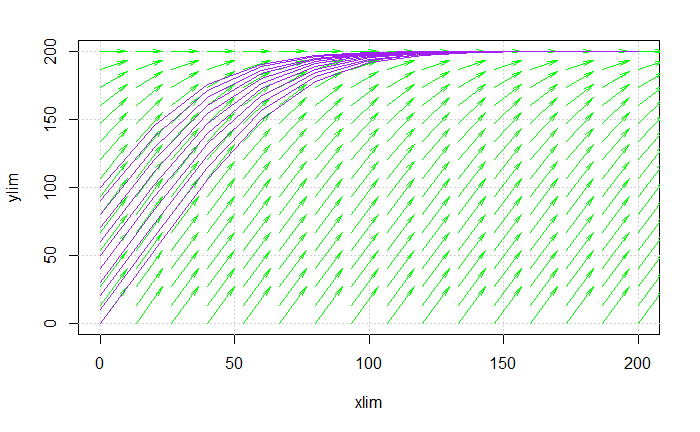

```r
#install.packages("phaseR")
#library(phaseR)
library(pracma)
metodoEuler <- function(f, h, xi, yi, xf)
{
  N = (xf - xi) / h
  x = y = numeric(N+1)
  x[1] = xi;
  y[1] = yi;
  i = 1
  while (i <= N)
  {
    x[i+1] = x[i]+h
    y[i+1] = y[i]+(h*f(x[i],y[i]))
    i = i+1
  }
  return (data.frame(X = x, Y = y))
}
f <- function(x,y) {(-5.6e-8*6*0.5*(((y^4))-200^4))/(1*100)}
e1 = metodoEuler(f,10,0,100,200)
e1[nrow(e1),]

xx <- c(0, 200); yy <- c(0, 200)
vectorfield(f, xx, yy, scale = 10)
for (xs in seq(0, 100, by = 10))
{
  sol <- rk4(f, 0, 200, xs, 10)
  lines(sol$x, sol$y, col="purple")
}
```

3. Metodo de Taylor:

   Para el segundo punto del taller se implementará el metodo de Taylor para generar solucion a la ecuacion con una condicion inicial de y(0)=1.

| X | Y | E |
| --- | --- | --- |
| 0.0 | 1.000000 | 0.0000000 |
| 0.1 | 1.206000 | 0.2060000 |
| 0.2 | 1.442778 | 0.2367780 |
| 0.3 | 1.711571 | 0.2687931 |
| 0.4 | 2.013747 | 0.3021757 |
| 0.5 | 2.350817 | 0.3370703 |

```r
TaylorO2 = function(f, h, xi, yi, xf){
  N = (xf - xi) / h
  x = y = e = numeric(N+1)
  x[1] = xi;
  y[1] = yi;
  e[1] = 0
  i = 1
  while (i <= N)
  {
    x[i+1] = x[i]+h
    w = y[i]+h*f(x[i],y[i])
    y[i+1] = y[i]+(h*f(x[i],y[i]))+((h^2/2)*w)
    e[i+1] = abs(y[i+1]-y[i])
    i = i+1
  }
  return (data.frame(X = x, Y = y, E = e))
}
par(mfrow=c(1,1))
f <- function(x, y) {1-x^2+(x+y)}
respuesta = function(x){return(exp(x)*(x^2*exp(-x)+x*exp(-x)+1))}
x = seq(0,0.5,by=0.1)
t1 = TaylorO2(f, 0.1, 0, 1, 0.5)
t1

plot(t1$X,t1$Y,type="l",asp=1,xlab="x",ylab="y",col="blue")
lines(x,respuesta(x),col="green")
```

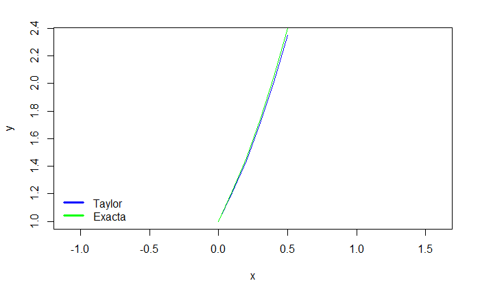

```r
legend("bottomleft",col=c("blue","green"),legend =c("Taylor","Exacta"), lwd=3, bty = "n")
```

4. Ecuación implementando metodo de Euler:

   Para el tercer punto del taller se implementara el metodo de Euler para generar la solucion de la ecuacion con una condicion inicial de y(0)=1.
   1. Análisis de la solción:

      Para calcular el error de la solución real y del metodo de euler, calcularemos la solucion de dicha ecuacion por ambos metodos, para la solución real utilizaremos la siguiente función exp(x)*(x^2*exp(-x)+x*exp(-x)+1). Ademas para el calculo del metodo de Euler, tendra como x inicial 0, y inicial 1 , x final 10, se desarrollara con un intervalo de z entre -3 y 3 y para y entre -1 y 1.
   2. Codigo y respuestas de la solucion:

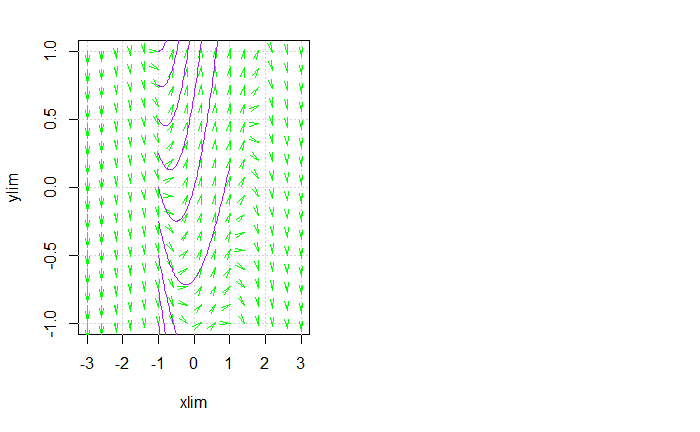

```r
metodoEuler <-function(f, h, xi, yi, xf)
{
  N = (xf - xi) / h
  x = y = numeric(N+1)
  x[1] = xi;
  y[1] = yi;
  i = 1
  while (i <= N)
  {
    x[i+1] = x[i]+h
    y[i+1] = y[i]+(h*f(x[i],y[i]))
    i = i+1
  }
  return (data.frame(X = x, Y = y))
}
f <- function(x, y) {(x+y)-(x^2)+1}
eul = metodoEuler(f, 0.1, 0, 1, 10)
par(mfrow=c(1,2))
xx <- c(-3, 3); yy <- c(-1, 1)
x <- seq(1, 20, by=1)
y <- seq(1, 20, by=1)
vectorfield(f, xx, yy, scale = 0.01)
for(xs in seq(-1, 1, by = 0.25)){
  sol <- pracma::rk4(f, -1, 1, xs, 100)
  lines(sol$x, sol$y, col="purple")
}
Solucion <- function(x){
  return (exp(x)*(x^2*exp(-x)+x*exp(-x)+1))
}
for (i in 1:20){
  cat("  x  "," ","  Sol.Euler  ","","  Sol.Exacta  ","" ,"  Error  ","\n")
  cat(" ",eul[i, 1], "  " , eul[i, 2], "      ",Solucion(eul[i, 1]), "      ",Solucion(eul[i, 1])-eul[i, 2],"\n")
  x[i] = eul[i, 1]
  y[i] = eul[i, 2]

}
```

```
  x       Sol.Euler      Sol.Exacta      Error
  0    1        1        0
  x       Sol.Euler      Sol.Exacta      Error
  0.1    1.2        1.215171        0.01517092
  x       Sol.Euler      Sol.Exacta      Error
  0.2    1.429        1.461403        0.03240276
  x       Sol.Euler      Sol.Exacta      Error
  0.3    1.6879        1.739859        0.05195881
  x       Sol.Euler      Sol.Exacta      Error
  0.4    1.97769        2.051825        0.0741347
  x       Sol.Euler      Sol.Exacta      Error
  0.5    2.299459        2.398721        0.09926227
  x       Sol.Euler      Sol.Exacta      Error
  0.6    2.654405        2.782119        0.1277139
  x       Sol.Euler      Sol.Exacta      Error
  0.7    3.043845        3.203753        0.1599073
  x       Sol.Euler      Sol.Exacta      Error
  0.8    3.46923        3.665541        0.196311
  x       Sol.Euler      Sol.Exacta      Error
  0.9    3.932153        4.169603        0.2374502
  x       Sol.Euler      Sol.Exacta      Error
  1    4.434368        4.718282        0.2839136
  x       Sol.Euler      Sol.Exacta      Error
  1.1    4.977805        5.314166        0.336361
  x       Sol.Euler      Sol.Exacta      Error
  1.2    5.564586        5.960117        0.3955314
  x       Sol.Euler      Sol.Exacta      Error
  1.3    6.197044        6.659297        0.4622526
  x       Sol.Euler      Sol.Exacta      Error
  1.4    6.877749        7.4152        0.5374515
  x       Sol.Euler      Sol.Exacta      Error
  1.5    7.609523        8.231689        0.6221657
  x       Sol.Euler      Sol.Exacta      Error
  1.6    8.395476        9.113032        0.7175567
  x       Sol.Euler      Sol.Exacta      Error
  1.7    9.239023        10.06395        0.8249241
  x       Sol.Euler      Sol.Exacta      Error
  1.8    10.14393        11.08965        0.9457219
  x       Sol.Euler      Sol.Exacta      Error
  1.9    11.11432        12.19589        1.081576
```

5. Implementación de un algoritmo y solución:

   Para el 4 punto, implementaremos el pseudocodigo dado en el taller y generaremos una solucion de la ecuación resuelta en el punto anterior.

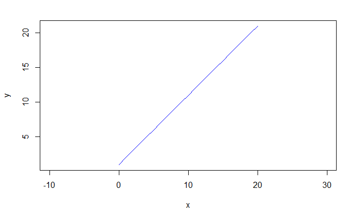

```r
f <- function(x, y) {1-(x^2)+x+y}
solucion <- function(x){return (exp(x)*(x^2*exp(-x)+x*exp(-x)+1))}
m <- 20
h <- 0.1
x <-seq(0,20,by=1)
y <-seq(1,21,by=1)
plot(x, y, type="l",asp=1,col="blue")
for (i in 1:m){
  k1=h*f(x[i],y[i])
  k2=h*f(x[i]+h,y[i]+k1)
  y[i+1]=y[i]+((1/2)*(k1+k2))
  x[i+1]=x[i]+h

  cat("  x  "," ","  Sol.Exacta  ","\n")
  cat(" ",x[i], "  " ,Solucion(x[i]),"\n")
}
```

```
  x       Sol.Exacta
  0    1
  x       Sol.Exacta
  0.1    1.215171
  x       Sol.Exacta
  0.2    1.461403
  x       Sol.Exacta
  0.3    1.739859
  x       Sol.Exacta
  0.4    2.051825
  x       Sol.Exacta
  0.5    2.398721
  x       Sol.Exacta
  0.6    2.782119
  x       Sol.Exacta
  0.7    3.203753
  x       Sol.Exacta
  0.8    3.665541
  x       Sol.Exacta
  0.9    4.169603
  x       Sol.Exacta
  1    4.718282
  x       Sol.Exacta
  1.1    5.314166
  x       Sol.Exacta
  1.2    5.960117
  x       Sol.Exacta
  1.3    6.659297
  x       Sol.Exacta
  1.4    7.4152
  x       Sol.Exacta
  1.5    8.231689
  x       Sol.Exacta
  1.6    9.113032
  x       Sol.Exacta
  1.7    10.06395
  x       Sol.Exacta
  1.8    11.08965
  x       Sol.Exacta
  1.9    12.19589
```

6. codigo para resolver por Euler una ecuacion diferencial ordinaria de primer orden

[output not shown]

```r
metodoEuler <- function(f, h, xi, yi, xf){
  N = (xf - xi) / h
  x = y = numeric(N+1)
  x[1] = xi;
  y[1] = yi;
  i = 1
  while (i <= N)
  {
    x[i+1] = x[i]+h
    y[i+1] = y[i]+(h*f(x[i],y[i]))
    i = i+1
  }
  return (data.frame(X = x, Y = y))
}
x = seq(0,1,by=0.1)
f<-function(x, y) {(x+y)-(x^2)+1}
eul1 = metodoEuler(f,0.1,0,1,0.9)
eul1[,]

eul2 = varEuler(f,0.1,0,1,0.9)
eul2[,]
```

| X | Y |
| --- | --- |
| 0.0 | 1.000000 |
| 0.1 | 1.214500 |
| 0.2 | 1.459973 |
| 0.3 | 1.737570 |
| 0.4 | 2.048564 |
| 0.5 | 2.394364 |
| 0.6 | 2.776522 |
| 0.7 | 3.196757 |
| 0.8 | 3.656966 |
| 0.9 | 4.159248 |

7.Codigo de Runge Kutta de tercer y cuarto orden comparado con metodo de Euler

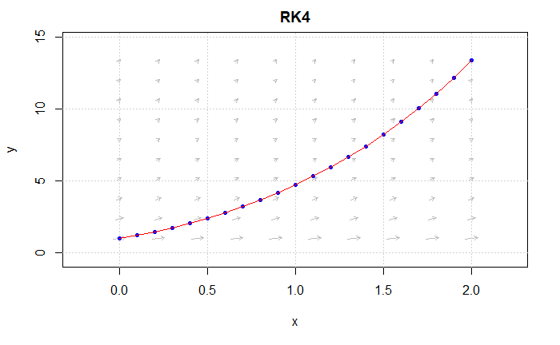

```r
#install.packages("phaseR")
install.packages("pracma")
#library(phaseR)
library(pracma)
list.of.packages <- c("phaseR")
new.packages <- list.of.packages[!(list.of.packages %in% installed.packages()[,"Package"])]
if(length(new.packages)) install.packages(new.packages)
library(phaseR)
f<-function(fcn,x,y){
  return(eval(fcn))
}
# Solo para prueba con dy=x+y, y(0)=1
obtenerErrorAbsoluto<-function(x,y){
  solucion=exp(x)*((-x*exp(-x))-exp(-x)+2)
  return(abs(y-solucion))
}
graficarCampoPendiente<-function(x0, xn, y0, yn, fcn, numpendientes, metodo){
  apma1 <- function(t, y, parameters){
    a <- parameters[1]
    dy <- a*(f(fcn, t, y))
    list(dy)
  }
  apma1.flowField <- flowField(apma1, x = c(x0, xn),
                               y   = c(y0, yn), parameters = c(1),
                               points = numpendientes, system = "one.dim",
                               add = FALSE, xlab = "x", ylab = "y",
                               main = metodo)
  grid()
}
graficarSolucionNumerica<-function (x, y){
  points (x, y, pch=20, col="blue")
  for (i in 2:length(x)){
    segments(x[i-1], y[i-1], x[i], y[i], col="red")
  }
}
rk4<-function(dy, ti, tf, y0, h, graficar=TRUE, numpendientes=10){
  t<-seq(ti, tf, h)
  y<-c(y0)
 # cat("x    |y         |k1        |k2        |k3        |k4       |error absoluto\n")
  for(i in 2:length(t)){
    k1=h*f(dy, t[i-1], y[i-1])
    k2=h*f(dy, t[i-1]+h/2, y[i-1]+k1*(0.5))
    k3=h*f(dy, t[i-1]+h/2, y[i-1]+k2*(0.5))
    k4=h*f(dy, t[i-1]+h, y[i-1]+k3)
    y<-c(y, y[i-1]+1/6*(k1+2*k2+2*k3+k4))
  #  cat(t[i-1]," | ", y[i-1]," | ",k1," | ",k2," | ",k3," | ",k4," | ",obtenerErrorAbsoluto(t[i-1],y[i-1]),"\n")
  }
  if (graficar){
    graficarCampoPendiente(min(t), max(t), min(y), max(y), dy, numpendientes, "RK4")
    graficarSolucionNumerica(t, y)
  }
  rta<-list(w=y, t=t)
}
rk3<-function(dy, ti, tf, y0, h, graficar=TRUE, numpendientes=10){
  t<-seq(ti, tf, h)
  y<-c(y0)
  #cat("x    |y         |k1         |k2        |k3       |error absoluto\n")
  for(i in 2:length(t)){
    k1=h*f(dy, t[i-1], y[i-1])
    k2=h*f(dy, t[i-1]+h/2, y[i-1]+k1*(0.5))
    k3=h*f(dy, t[i-1]+h, y[i-1]-k1+2*k2)
    y<-c(y, y[i-1]+1/6*(k1+4*k2+k3))
  #  cat(t[i-1]," | ", y[i-1]," | ",k1," | ",k2," | ",k3," | ",obtenerErrorAbsoluto(t[i-1],y[i-1]),"\n")
  }
  if (graficar){
    graficarCampoPendiente(min(t), max(t), min(y), max(y), dy, numpendientes, "RK3")
    graficarSolucionNumerica(t, y)
  }
  rta<-list(w=y, t=t)
}
r4<-rk4(expression(x+y+1-x^2), 0, 2, 1, 0.1)
```

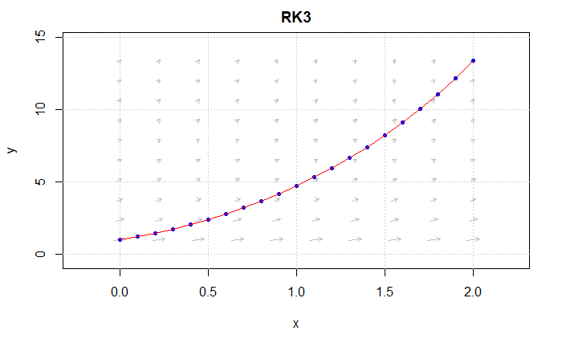

```r
r3<-rk3(expression(x+y+1-x^2), 0, 2, 1, 0.1)
metodoEuler <- function(f, h, xi, yi, xf){
  N = (xf - xi) / h
  x = y = numeric(N+1)
  x[1] = xi;
  y[1] = yi;
  i = 1
  while (i <= N)
  {
    x[i+1] = x[i]+h
    y[i+1] = y[i]+(h*f(x[i],y[i]))
    i = i+1
  }
  return (data.frame(X = x, Y = y))
}
funcion <- function(x){return (exp(x)*(x^2*exp(-x)+x*exp(-x)+1))}
par(mfrow=c(1,3))
```

```r
r3<-rk3(expression(x+y+1-x^2), 0, 0.9, 1, 0.1)
r4<-rk4(expression(x+y+1-x^2), 0, 0.9, 1, 0.1)
```

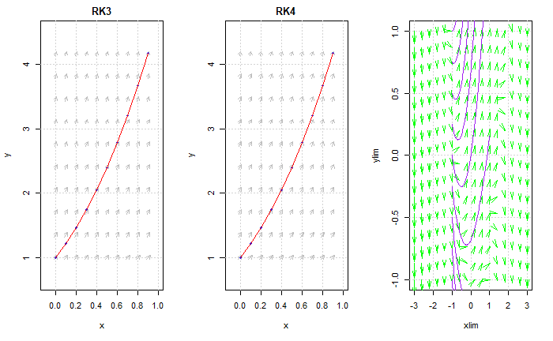

```r
f <- function(x, y) {(x+y)-(x^2)+1}
eul = metodoEuler(f, 0.1, 0, 1, 0.9)
xx <- c(-3, 3); yy <- c(-1, 1)
vectorfield(f, xx, yy, scale = 0.01)
for (xs in seq(-1, 1, by = 0.25)){
  sol <- pracma::rk4(f, -1, 1, xs, 100)
  lines(sol$x, sol$y, col="purple")
}
```

```r
for(i in 1:10){
  k3=r3[[1]]
  k4=r4[[1]]
  cat("  x  "," ","  Sol.Euler  ","","  Sol.Exacta  "," " ,"  RK3  "," RK4","\n")
  cat(" ", eul[i,1], " ", eul[i,2]," " ,funcion(eul[i,1])," ",k3[i], " ", k4[i], "\n")
}
```

```
  x       Sol.Euler      Sol.Exacta       RK3    RK4
  0   1   1   1   1
  x       Sol.Euler      Sol.Exacta       RK3    RK4
  0.1   1.2   1.215171   1.215158   1.215171
  x       Sol.Euler      Sol.Exacta       RK3    RK4
  0.2   1.429   1.461403   1.461376   1.461402
  x       Sol.Euler      Sol.Exacta       RK3    RK4
  0.3   1.6879   1.739859   1.739816   1.739858
  x       Sol.Euler      Sol.Exacta       RK3    RK4
  0.4   1.97769   2.051825   2.051763   2.051823
  x       Sol.Euler      Sol.Exacta       RK3    RK4
  0.5   2.299459   2.398721   2.398638   2.398719
  x       Sol.Euler      Sol.Exacta       RK3    RK4
  0.6   2.654405   2.782119   2.782012   2.782116
  x       Sol.Euler      Sol.Exacta       RK3    RK4
  0.7   3.043845   3.203753   3.203618   3.20375
  x       Sol.Euler      Sol.Exacta       RK3    RK4
  0.8   3.46923   3.665541   3.665375   3.665537
  x       Sol.Euler      Sol.Exacta       RK3    RK4
  0.9   3.932153   4.169603   4.169402   4.169599
```